# Coding Challenge 4

Doug Terza

2026-02-19

# Question 1

## Explain the following

### a. YAML Headers

A YAML header providers the render markdown with a title, author, and date. It also provides selection of the type of output the render with be such as html, wword, or pdf document. Global commands are also avaible such as hiding th R chunks when rendered.

### b. Literate programming

Literate programming is writing code in a way that alows for machine rendering to be read and understood by a human. R markdown is an example of this.

# Question 2

## Take the code you wrote for coding challenge 3, question 5, and incorporate it into your R markdown file.

### a. Check out the paper here

[i. Noel, Z.A., Roze, L.V., Breunig, M., Trail, F. 2022. Endophytic fungi as promising biocontrol agent to protect wheat from Fusarium graminearum head blight. Plant Disease.](https://doi.org/10.1094/PDIS-06-21-1253-RE)

### b. Reading in the data csv file with a relative path

```r
knitr::opts_chunk$set(warning = FALSE)
data.toxin <- read.csv("MycotoxinData.csv", na.strings = "na")
data.toxin$Treatment <- factor(data.toxin$Treatment, levels = c("NTC", "Fg", "Fg + 37", "Fg + 40", "Fg + 70"))
str(data.toxin)
```

```
## 'data.frame':    375 obs. of  6 variables:
##  $ Treatment     : Factor w/ 5 levels "NTC","Fg","Fg + 37",..: 2 2 2 2 2 2 2 2 2 2 ...
##  $ Cultivar      : chr  "Wheaton" "Wheaton" "Wheaton" "Wheaton" ...
##  $ BioRep        : int  2 2 2 2 2 2 2 2 2 3 ...
##  $ MassperSeed_mg: num  10.29 12.8 2.85 6.5 10.18 ...
##  $ DON           : num  107.3 32.6 416 211.9 124 ...
##  $ X15ADON       : num  3 0.85 3.5 3.1 4.8 3.3 6.9 2.9 2.1 0.71 ...
```

### c. Make a separate code chunk for the figures plotting the DON data, 15ADON, and Seedmass, and one for the three combined using ggarrange.

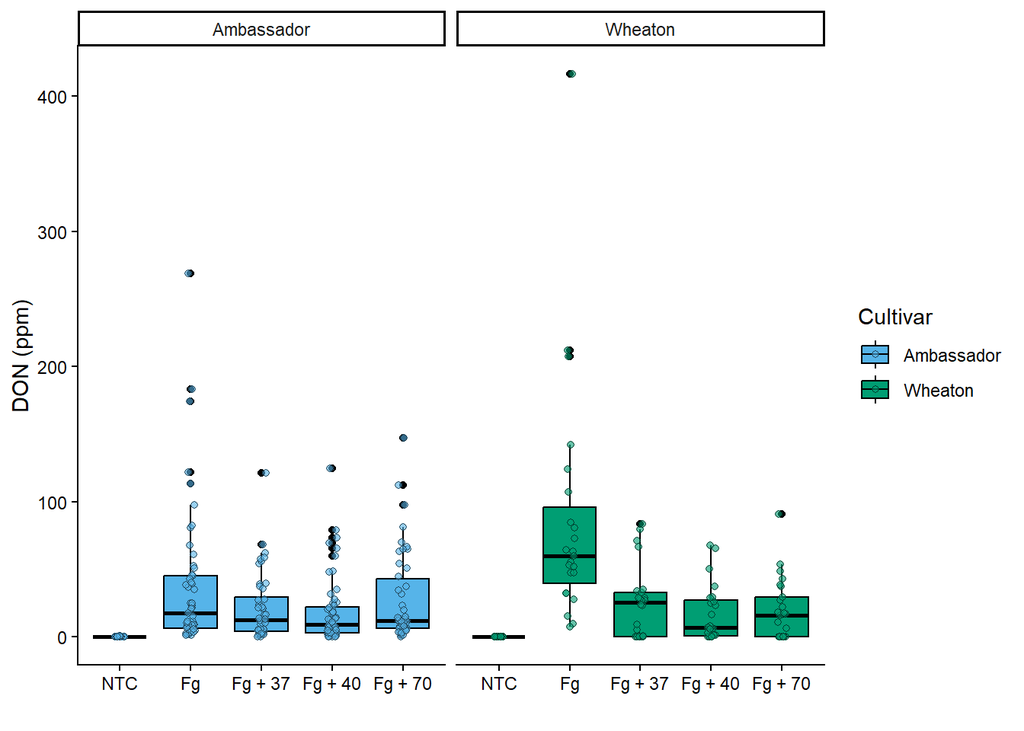

```r
cbbPalette <- c("#000000", "#E69F00", "#56B4E9", "#009E73", "#F0E442", "#0072B2", "#D55E00", "#CC79A7")

toxin.box4<- ggplot(data.toxin, aes(x = Treatment, y = DON, fill = Cultivar))+
  geom_boxplot(color= "#000000", position = position_dodge(width = 0.85))+
  scale_fill_manual(values = c("#56B4E9", "#009E73"))+
  geom_point(shape = 21, color = "#000000", alpha = 0.6, position = position_jitterdodge(jitter.width = 0.2, dodge.width = 0.85))+
  ylab("DON (ppm)")+
  xlab("")+
  scale_color_manual(values = c(cbbPalette[[3]], cbbPalette[[4]]), name = "Cultivar", labels = c("Ambassador", "Wheaton"))+
  theme_classic()+
  facet_wrap(~Cultivar)
toxin.box4
```

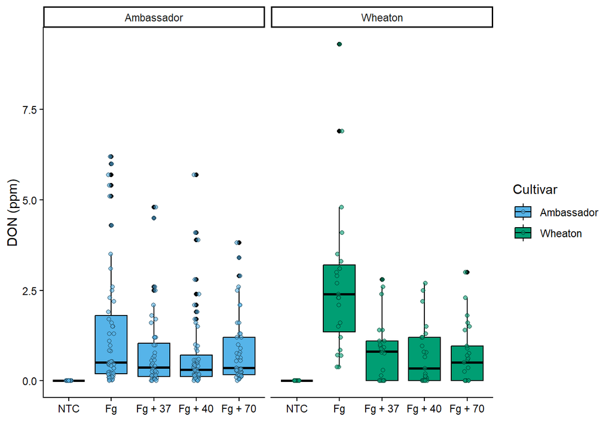

```r
toxin.box5<- ggplot(data.toxin, aes(x = Treatment, y = X15ADON, fill = Cultivar))+
  geom_boxplot(color= "#000000", position = position_dodge(width = 0.85))+
  scale_fill_manual(values = c("#56B4E9", "#009E73"))+
  geom_point(shape = 21, color = "#000000", alpha = 0.6, position = position_jitterdodge(jitter.width = 0.2, dodge.width = 0.85))+
  ylab("DON (ppm)")+
  xlab("")+
  scale_color_manual(values = c(cbbPalette[[3]], cbbPalette[[4]]), name = "Cultivar", labels = c("Ambassador", "Wheaton"))+
  theme_classic()+
  facet_wrap(~Cultivar)
toxin.box5
```

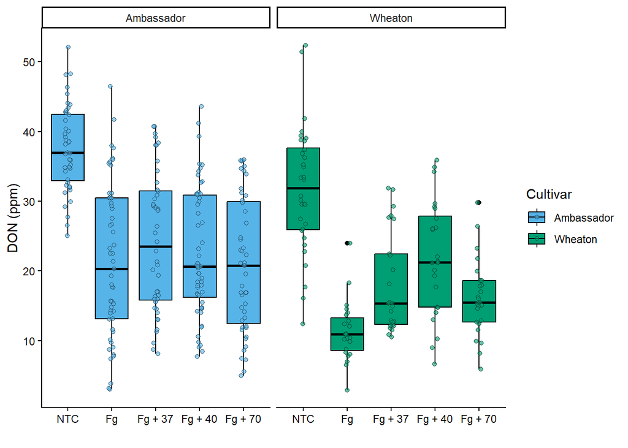

```r
toxin.box6<- ggplot(data.toxin, aes(x = Treatment, y = MassperSeed_mg, fill = Cultivar))+
  geom_boxplot(color= "#000000", position = position_dodge(width = 0.85))+
  scale_fill_manual(values = c("#56B4E9", "#009E73"))+
  geom_point(shape = 21, color = "#000000", alpha = 0.6, position = position_jitterdodge(jitter.width = 0.2, dodge.width = 0.85))+
  ylab("DON (ppm)")+
  xlab("")+
  scale_color_manual(values = c(cbbPalette[[3]], cbbPalette[[4]]), name = "Cultivar", labels = c("Ambassador", "Wheaton"))+
  theme_classic()+
  facet_wrap(~Cultivar)
toxin.box6
```

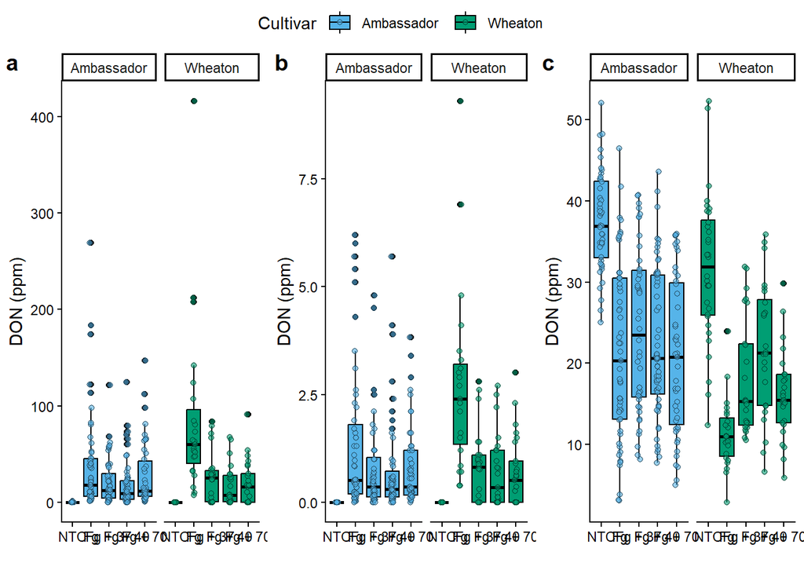

```r
toxin.box7<- ggarrange(toxin.box4, toxin.box5, toxin.box6,
                       labels = "auto",
                       nrow = 1,
                       ncol= 3,
                       common.legend = TRUE)
toxin.box7
```

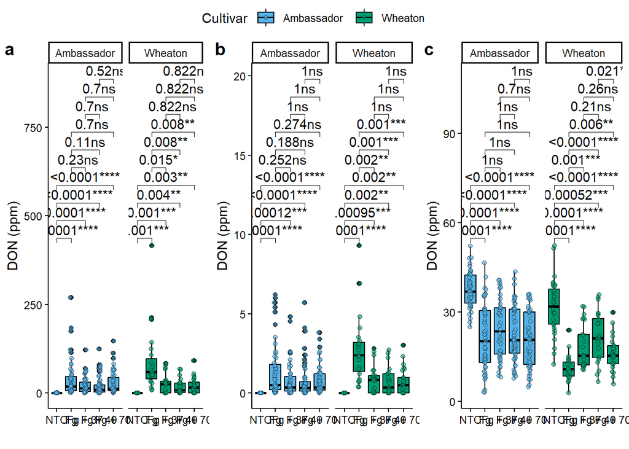

```r
toxin.box8<-ggarrange((toxin.box4+
  geom_pwc(aes(group = Treatment), method = "t_test", label = "{p.adj.format}{p.adj.signif}")),
  toxin.box5+
  geom_pwc(aes(group = Treatment), method = "t_test", label = "{p.adj.format}{p.adj.signif}"),
  toxin.box6+
  geom_pwc(aes(group = Treatment), method = "t_test", label = "{p.adj.format}{p.adj.signif}"),
  labels = "auto",
  nrow = 1,
  ncol = 3,
  common.legend = TRUE)
toxin.box8
```

# Question 3

## Knit your document together in the following formats:

# Question 4

## Push the .docx or .pdf and .md files to GitHub inside a directory called Coding Challenge 4.

# Question 5

## Now edit, commit, and push the README file for your repository and include the following elements.

### a. A clickable link in your README to your GitHub flavored .md file

### b. A file tree of your GitHub repository.

# Question 6

## Please turn in the file generated in question 3a to canvas with a clickable link to your GitHub repository within the document.